# Parallelization Example

- Show All Code
- Hide All Code
- View Source

Author

Prof. Tiffany Tang

Published

March 6, 2026

## Load Data

```r
# load in TCGA breast cancer data
X <- load_brca_data(DATA_PATH) |>
  apply_log_transform()
y <- as.factor(load_subtype_data(DATA_PATH)$subtype)
```

```r
head(X[, 1:5])
```

```
# A tibble: 6 × 5
   NAT1  NAT2 RP11.986E7.7 AADAC  ABAT
  <dbl> <dbl>        <dbl> <dbl> <dbl>
1  7.40 0.933        10.9  0.572  7.72
2  9.38 3.73         10.1  1.39   7.46
3  7.76 3.12         10.7  0      8.46
4  6.16 1.41          7.34 0      6.22
5  4.40 1.23          8.20 0.710  5.88
6  4.34 0.367         9.68 0      7.38
```

```r
head(y)
```

```
[1] LumA LumB LumA LumB Her2 LumA
Levels: Basal Her2 LumA LumB
```

## Fitting leave-one-out models

For the sake of this demonstration, suppose that we want to evaluate the performance of a random forest model on this data using leave-one-out cross-validation (also known as the *jackknife* in statistics). The jackknife is a useful technique for estimating the bias and variance of a statistical model/estimator and can also be used to identify influential observations (i.e., those observations that have a large impact on the model’s performance).

To do so, there is a helper function `fit_rf_loo()` in `R/fit.R` that takes in the covariate data `X`, the response variable `y`, and the index of the observation to leave out `i`. This function `fit_rf_loo()` fits a random forest model on the data with the `i`-th observation left out and returns the predicted class of the left-out `i`-th observation.

```r
fit_rf_loo
```

```
function (i, x, y, ...)
{
    fit <- ranger::ranger(x = x[-i, , drop = FALSE], y = y[-i],
        num.threads = 1, ...)
    preds <- as.character(predict(fit, x[i, , drop = FALSE])$predictions)
    return(preds)
}
```

## Without Parallelization

Let’s first run the leave-one-out cross-validation without parallelization to see how long it takes. We will only run this on the first `n = 10` observations for demonstration purposes.

```r
set.seed(242)
start_time <- Sys.time()
preds <- rep(NA, n) # vector of leave-one-out predictions
for (i in 1:n) {
  preds[i] <- fit_rf_loo(i, X, y)
}
end_time <- Sys.time()
execution_time <- end_time - start_time
print(execution_time)
```

```
Time difference of 43.90391 secs
```

## With Parallelization

Next, let’s run the leave-one-out cross-validation with parallelization using the `future` package. But before implementing this, let’s check how many cores are available on this machine using `future::availableCores()`.

```r
availableCores()
```

```
system
    11
```

Now, to parallelize this code, there are two steps:

**Step 1: Setting up the parallel backend.** This is done using the `future::plan()` function, which specifies the parallel backend to use. Here, we will use the multisession backend, which creates multiple (independent) background R sessions to parallelize the computation.

**Step 2: Re-write the code using futures.** A future is an R object that represents the result of an expression that will be evaluated in the future. We can create a future using the `future::future()` function and extract the value of the future using the `future::value()` function.

- A future can be resolved or unresolved. We can check whether a future is resolved using the `future::resolved()` function.
- If the value is queried while the future is still unresolved, the current process is blocked until the future is resolved. Otherwise, the code continues to execute (i.e., it’s unblocking).

```r
set.seed(242)

# step 1: set up parallel backend
n_workers <- 5
plan(multisession, workers = n_workers)

start_time <- Sys.time()
futures <- list()
for (i in 1:n) {
  # step 2: wrap code in a "future" object
  futures[[i]] <- future({
    fit_rf_loo(i, X, y)
  }, seed = TRUE)
  # (optional) checking whether the future we created has been resolved or unresolved
  print(resolved(futures))
  print(paste("Intermediary Time Checkpoint:", Sys.time() - start_time))
}
preds_future <- lapply(futures, value)
end_time <- Sys.time()
execution_time <- end_time - start_time
print(paste("Final Time Checkpoint:", execution_time))
```

```
[1] FALSE
[1] "Intermediary Time Checkpoint: 0.117080926895142"
[1] FALSE FALSE
[1] "Intermediary Time Checkpoint: 0.229812860488892"
[1] FALSE FALSE FALSE
[1] "Intermediary Time Checkpoint: 0.366296052932739"
[1] FALSE FALSE FALSE FALSE
[1] "Intermediary Time Checkpoint: 0.506423950195312"
[1] FALSE FALSE FALSE FALSE FALSE
[1] "Intermediary Time Checkpoint: 0.689152002334595"
[1]  TRUE  TRUE FALSE FALSE FALSE FALSE
[1] "Intermediary Time Checkpoint: 5.56400084495544"
[1]  TRUE  TRUE  TRUE FALSE FALSE FALSE FALSE
[1] "Intermediary Time Checkpoint: 5.72000002861023"
[1]  TRUE  TRUE  TRUE  TRUE FALSE FALSE FALSE FALSE
[1] "Intermediary Time Checkpoint: 5.86646795272827"
[1]  TRUE  TRUE  TRUE  TRUE  TRUE FALSE FALSE FALSE FALSE
[1] "Intermediary Time Checkpoint: 6.01877188682556"
 [1]  TRUE  TRUE  TRUE  TRUE  TRUE FALSE FALSE FALSE FALSE FALSE
[1] "Intermediary Time Checkpoint: 6.19236898422241"
[1] "Final Time Checkpoint: 10.8971419334412"
```

Note:

- The futures are “non-blocking” so that the code continues to run (while the futures are being computed in the background) until it reaches a point where the value of the future is needed. This is why the print statement shows that the futures are at first unresolved and there is a time gap between the intermediary checkpoint and the final checkpoint.
- The futures are resolved when the `value()` function is called, and the code waits for the future to be resolved before continuing.

Sometimes, it can be more convenient to rewrite the for loop using the `furrr` package, which provides a functional programming interface for parallel programming in R. The `furrr::future_map()` function is similar to the `purrr::map()` function, but it runs the function in parallel using futures.

```r
set.seed(242)
# step 1: set up parallel backend
plan(multisession, workers = n_workers)
start_time <- Sys.time()
# step 2: wrap code in a "future" object
preds_furrr <- furrr::future_map(
  1:n,
  function(i) {
    fit_rf_loo(i, X, y)
  },
  .options = furrr::furrr_options(seed = TRUE)
)
end_time <- Sys.time()
execution_time <- end_time - start_time
print(execution_time)
```

```
Time difference of 14.18395 secs
```

## Parallelization backends

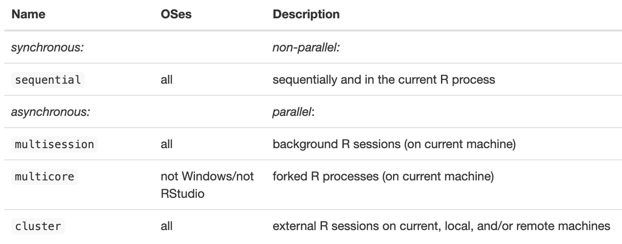

In short, use `multisession` if running R locally in RStudio, and use `multicore` for simple parallelization workflows on the CRC.

## Additional Resources/Links

- **future: https://future.futureverse.org/articles/future-1-overview.html**
- **furrr: https://furrr.futureverse.org/**
  - Offers drop-in replacements for parallelizing purrr::map() functions
- **future.apply: https://future.apply.futureverse.org/**
  - Offers drop-in replacements for parallelizing base R apply() functions
- **doFuture: https://dofuture.futureverse.org/**
  - The “futureverse” version of the doParallel R package

Stay up-to-date with the latest developments in the futureverse:  
https://www.futureverse.org/blog.html